# Selección de variables

**Elaborado por:** Jacqueline Fernández Ramírez, Jazmín Fernández Ramírez y Nina Odoux.

Máster universitario de Ciencia de Datos (MUCD) - CUNEF Universidad.

La selección de variables es un proceso en el cual se escogen automáticamente las características de los datos que más contribuyen a la variable objetivo. La presencia de variables irrelevantes puede reducir la precisión de algunos modelos, especialmente en algoritmos lineales como la regresión lineal y logística.

Tres beneficios de realizar la selección de características antes de modelar sus datos son:

- **Reducción del sobreajuste:** Mejora la precisión en algunos modelos, ya que menos datos redundantes significan menos oportunidades de tomar decisiones basadas en el ruido.
- **Mejora del rendimiento del modelo:** Al eliminar variables irrelevantes, se puede mejorar la precisión y la interpretabilidad del modelo.
- **Reducción del tiempo de entrenamiento:** Con menos datos, los algoritmos se entrenan más rápido, lo cual ahorra tiempo y recursos computacionales.

## Importación de librerías

```python
import pandas as pd
import numpy as np
import sklearn
from sklearn.pipeline import Pipeline
from sklearn import metrics

import category_encoders as ce
from sklearn.preprocessing import OneHotEncoder
from sklearn.decomposition import PCA
from sklearn.linear_model import Ridge, Lasso
from sklearn.metrics import mean_squared_error
import matplotlib.pyplot as plt
import seaborn as sns
from sklearn.ensemble import RandomForestClassifier, GradientBoostingClassifier
from sklearn import metrics
from sklearn.metrics import plot_confusion_matrix, roc_curve, roc_auc_score
from sklearn.linear_model import Lasso, LogisticRegression
from sklearn.feature_selection import SelectFromModel, RFE
from sklearn.preprocessing import StandardScaler
from sklearn.tree import DecisionTreeClassifier
from sklearn.impute import SimpleImputer
from boruta import BorutaPy
```

### Fijación de semilla

```python
seed = np.random.seed(123)
```

## Lectura del dataset: train y test

```python
X_train_scaled = pd.read_csv("../data/preprocessed_data/X_train_preprocessing_scaled.csv")
X_test_scaled = pd.read_csv("../data/preprocessed_data/X_test_preprocessing_scaled.csv")
```

```python
X_train_scaled.columns
```

```
Index(['AMT_ANNUITY', 'AMT_CREDIT', 'AMT_GOODS_PRICE', 'AMT_INCOME_TOTAL',
       'AMT_REQ_CREDIT_BUREAU_DAY', 'AMT_REQ_CREDIT_BUREAU_HOUR',
       'AMT_REQ_CREDIT_BUREAU_MON', 'AMT_REQ_CREDIT_BUREAU_QRT',
       'AMT_REQ_CREDIT_BUREAU_WEEK', 'AMT_REQ_CREDIT_BUREAU_YEAR',
       ...
       'WEEKDAY_APPR_PROCESS_START_SUNDAY',
       'WEEKDAY_APPR_PROCESS_START_THURSDAY',
       'WEEKDAY_APPR_PROCESS_START_TUESDAY',
       'WEEKDAY_APPR_PROCESS_START_WEDNESDAY', 'YEARS_BEGINEXPLUATATION_AVG',
       'YEARS_BEGINEXPLUATATION_MEDI', 'YEARS_BEGINEXPLUATATION_MODE',
       'YEARS_BUILD_AVG', 'YEARS_BUILD_MEDI', 'YEARS_BUILD_MODE'],
      dtype='object', length=176)
```

```python
X_test_scaled.columns
```

```
Index(['AMT_ANNUITY', 'AMT_CREDIT', 'AMT_GOODS_PRICE', 'AMT_INCOME_TOTAL',
       'AMT_REQ_CREDIT_BUREAU_DAY', 'AMT_REQ_CREDIT_BUREAU_HOUR',
       'AMT_REQ_CREDIT_BUREAU_MON', 'AMT_REQ_CREDIT_BUREAU_QRT',
       'AMT_REQ_CREDIT_BUREAU_WEEK', 'AMT_REQ_CREDIT_BUREAU_YEAR',
       ...
       'WEEKDAY_APPR_PROCESS_START_SUNDAY',
       'WEEKDAY_APPR_PROCESS_START_THURSDAY',
       'WEEKDAY_APPR_PROCESS_START_TUESDAY',
       'WEEKDAY_APPR_PROCESS_START_WEDNESDAY', 'YEARS_BEGINEXPLUATATION_AVG',
       'YEARS_BEGINEXPLUATATION_MEDI', 'YEARS_BEGINEXPLUATATION_MODE',
       'YEARS_BUILD_AVG', 'YEARS_BUILD_MEDI', 'YEARS_BUILD_MODE'],
      dtype='object', length=176)
```

```python
y_train = pd.read_csv("../data/preprocessed_data/y_train_preprocessing_scaled.csv")
y_test = pd.read_csv("../data/preprocessed_data/y_test_preprocessing_scaled.csv")
```

## Tratamiento de NaN

Primeramente, es importante asegurar que todos los NaN sean manejados adecuadamente.

```python
# Count NaN values per column
nan_counts_train = X_train_scaled.isna().sum()
nan_percentage_train = (nan_counts_train / X_train_scaled.shape[0]) * 100

nan_counts_test = X_test_scaled.isna().sum()
nan_percentage_test = (nan_counts_test / X_test_scaled.shape[0]) * 100

# Display columns with NaN values and their percentages
print("NaN values in the training set:")
print(pd.DataFrame({'Nan_count': nan_counts_train, 'Nan_percentage': nan_percentage_train}).query('Nan_count > 0'))

print("NaN values in the test set:")
print(pd.DataFrame({'Nan_count': nan_counts_test, 'Nan_percentage': nan_percentage_test}).query('Nan_count > 0'))
```

```
NaN values in the training set:
                                 Nan_count  Nan_percentage
DAYS_REGISTRATION                      812        0.330071
DEF_30_CNT_SOCIAL_CIRCLE               812        0.330071
ENTRANCES_MEDI                      138528       56.310364
ENTRANCES_MODE                         516        0.209749
EXT_SOURCE_1                         48974       19.907483
NAME_TYPE_SUITE_Group of people        812        0.330071
NAME_TYPE_SUITE_NO VALUE               812        0.330071
NAME_TYPE_SUITE_Other_A             162329       65.985253
NaN values in the test set:
                                 Nan_count  Nan_percentage
DAYS_REGISTRATION                      209        0.339821
DEF_30_CNT_SOCIAL_CIRCLE               209        0.339821
ENTRANCES_MEDI                       34850       56.663903
ENTRANCES_MODE                         144        0.234135
EXT_SOURCE_1                         11991       19.496610
NAME_TYPE_SUITE_Group of people        209        0.339821
NAME_TYPE_SUITE_NO VALUE               209        0.339821
NAME_TYPE_SUITE_Other_A              40600       66.013040
```

```python
# Define the columns to drop
cols_to_drop = ['ENTRANCES_MEDI', 'NAME_TYPE_SUITE_Other_B']

# Drop columns in the training and test sets
X_train_scaled.drop(columns=cols_to_drop, inplace=True)
X_test_scaled.drop(columns=cols_to_drop, inplace=True)

# Verify the deletion
print(f"Columns dropped: {cols_to_drop}")
print("New dimensions of the training set:", X_train_scaled.shape)
print("New dimensions of the test set:", X_test_scaled.shape)
```

```
Columns dropped: ['ENTRANCES_MEDI', 'NAME_TYPE_SUITE_Other_B']
New dimensions of the training set: (246008, 174)
New dimensions of the test set: (61503, 174)
```

```python
# Remove whitespace from column names

X_train_scaled.columns = X_train_scaled.columns.str.strip()
X_test_scaled.columns = X_test_scaled.columns.str.strip()
```

```python
# Ensure all column names are in lowercase to avoid discrepancies

X_train_scaled.columns = X_train_scaled.columns.str.lower()
X_test_scaled.columns = X_test_scaled.columns.str.lower()
```

```python
# Replace infinite values with NaN
X_train_scaled.replace([np.inf, -np.inf], np.nan, inplace=True)
X_test_scaled.replace([np.inf, -np.inf], np.nan, inplace=True)

# Separate numerical columns
num_cols_train = X_train_scaled.select_dtypes(include=[np.number]).columns
num_cols_test = X_test_scaled.select_dtypes(include=[np.number]).columns

# Ensure that numerical columns are the same
missing_num_cols = set(num_cols_train) - set(num_cols_test)
for col in missing_num_cols:
    X_test_scaled[col] = np.nan

X_test_scaled = X_test_scaled[num_cols_train]

# Impute NaN values in numerical columns with the mean
num_imputer = SimpleImputer(strategy='mean')
X_train_scaled[num_cols_train] = num_imputer.fit_transform(X_train_scaled[num_cols_train])
X_test_scaled[num_cols_train] = num_imputer.transform(X_test_scaled[num_cols_train])

# Count rows after imputation
total_rows_train_after = X_train_scaled.shape[0]
total_rows_test_after = X_test_scaled.shape[0]

print("Total rows in X_train_scaled after imputation:", total_rows_train_after)
print("Total rows in X_test_scaled after imputation:", total_rows_test_after)
```

```
Total rows in X_train_scaled after imputation: 246008
Total rows in X_test_scaled after imputation: 61503
```

Durante el proceso de preprocesamiento de datos, se realizó la imputación de valores faltantes en los conjuntos de datos de entrenamiento y prueba utilizando la técnica de imputación con la media para las columnas numéricas. Los resultados de este procedimiento son los siguientes:

- **Número de Filas en los Conjuntos de Datos:**
- Conjunto de Datos de Entrenamiento (X_train_scaled): 246,008 filas
- Conjunto de Datos de Prueba (X_test_scaled): 61,503 filas
- **Análisis de Resultados:** El número de filas en ambos conjuntos de datos después de la imputación se mantuvo intacto, indicando que el proceso no resultó en la eliminación de ninguna observación. Este resultado es positivo ya que preserva la cantidad de datos disponibles para el modelo de entrenamiento y evaluación, asegurando que no se pierde información valiosa en el proceso de preprocesamiento.
- **Implicaciones para el Modelo:** Mantener la integridad de los conjuntos de datos tras la imputación es crucial para garantizar que el modelo de aprendizaje automático tenga una cantidad suficiente de datos para aprender y generalizar adecuadamente. La imputación exitosa de los valores faltantes permite al modelo aprovechar todas las observaciones disponibles, mejorando potencialmente su rendimiento y capacidad predictiva.

# Selección preliminar de variables

## PCA | Análisis de componentes principales

Se aplica el PCA para la reducción de la dimensionalidad.

```python
# Ensure y_train and y_test are in the correct shape
y_train = np.ravel(y_train)
y_test = np.ravel(y_test)

# Apply PCA to reduce dimensionality
pca = PCA(n_components=0.95)  # Retain 95% of the variance
X_train_pca = pca.fit_transform(X_train_scaled)
X_test_pca = pca.transform(X_test_scaled)

print("Original dimensions:", X_train_scaled.shape[1])
print("Reduced dimensions with PCA:", X_train_pca.shape[1])
```

```
Original dimensions: 174
Reduced dimensions with PCA: 83
```

Se aplicó análisis de componentes Pprincipales (PCA) para reducir la dimensionalidad de los datos.

- **Reducción de Dimensionalidad con PCA**

Dimensiones originales: 174

Dimensiones reducidas: 83

Se utilizó el Análisis de Componentes Principales (PCA) para reducir la dimensionalidad del conjunto de datos. Este método permitió reducir el número de características de 174 dimensiones originales a 83 dimensiones, mientras se conservaba el 95% de la varianza total. La reducción resultante es significativa, ya que logra simplificar la complejidad de los datos sin perder información esencial para el análisis y la modelización.

## Ridge y Lasso

```
Ridge without PCA - MSE: 0.10035236775856786
Lasso without PCA - MSE: 0.07421079663022367
```

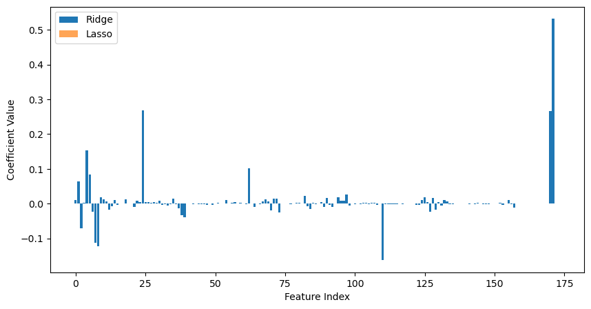

```python
# Ridge and Lasso on original data (without PCA)
ridge_orig = Ridge(alpha=1.0)
ridge_orig.fit(X_train_scaled, y_train)
y_pred_ridge_orig = ridge_orig.predict(X_test_scaled)
mse_ridge_orig = mean_squared_error(y_test, y_pred_ridge_orig)
print("Ridge without PCA - MSE:", mse_ridge_orig)

lasso_orig = Lasso(alpha=0.1)
lasso_orig.fit(X_train_scaled, y_train)
y_pred_lasso_orig = lasso_orig.predict(X_test_scaled)
mse_lasso_orig = mean_squared_error(y_test, y_pred_lasso_orig)
print("Lasso without PCA - MSE:", mse_lasso_orig)

# Plot the coefficients
plt.figure(figsize=(10, 5))
plt.bar(range(len(ridge_orig.coef_)), ridge_orig.coef_, label='Ridge')
plt.bar(range(len(lasso_orig.coef_)), lasso_orig.coef_, label='Lasso', alpha=0.7)
plt.xlabel("Feature Index")
plt.ylabel("Coefficient Value")
plt.legend()
plt.show()
```

**Ridge sin PCA - MSE: 0.1003**

El modelo Ridge intenta minimizar el error cuadrático medio penalizando grandes coeficientes para evitar el sobreajuste. Un MSE más alto aquí indica que el modelo tiene un peor ajuste a los datos en comparación con Lasso. Esto podría deberse a que Ridge utiliza todas las características (sin hacer selección explícita), lo que introduce ruido proveniente de variables irrelevantes o redundantes.

**Lasso sin PCA - MSE: 0.0742**

## Lasso

Lasso, acrónimo de "Least Absolute Shrinkage and Selection Operator", es una técnica empleada en el ámbito de la estadística y el aprendizaje automático. Su propósito principal es mejorar tanto la precisión como la interpretabilidad de los modelos predictivos.

Mediante la aplicación de una penalización específica, Lasso facilita la selección automática de variables relevantes, al tiempo que reduce el impacto de aquellas menos significativas. Esta metodología ayuda a evitar el problema del sobreajuste, permitiendo que el modelo mantenga su simplicidad y robustez.

```
Evaluating Lasso with alpha=0.1
Lasso without PCA - MSE: 0.07421079663022367
Selected variables: 0
```

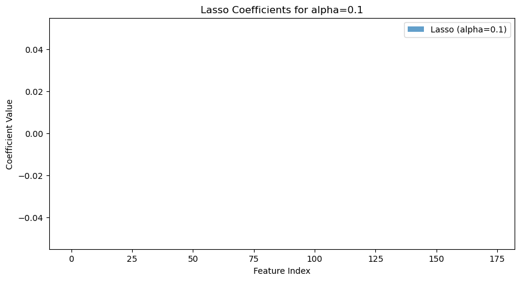

```
Evaluating Lasso with alpha=0.05
Lasso without PCA - MSE: 0.07421079663022367
Selected variables: 0
```

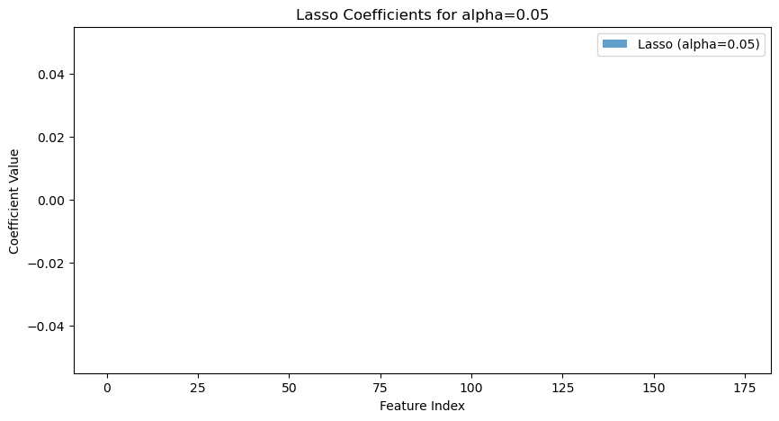

```
Evaluating Lasso with alpha=0.01
Lasso without PCA - MSE: 0.07103166923939107
Selected variables: 7
```

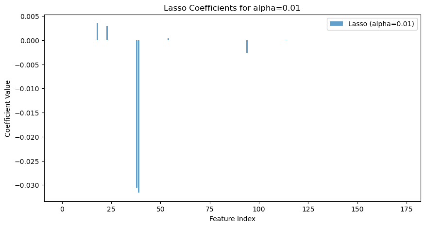

```
Evaluating Lasso with alpha=0.005
Lasso without PCA - MSE: 0.07077040776638042
Selected variables: 17
```

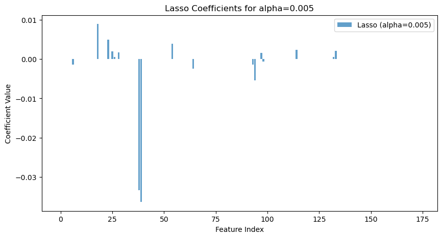

```
Evaluating Lasso with alpha=0.001
Lasso without PCA - MSE: 0.07053401458668707
Selected variables: 56
```

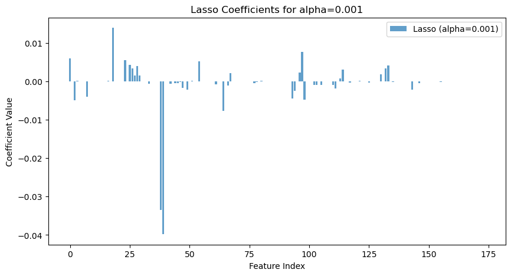

```python
# Test different values of alpha
alphas = [0.1, 0.05, 0.01, 0.005, 0.001]

for alpha in alphas:
    print(f"\nEvaluating Lasso with alpha={alpha}")
    # Lasso with the current value of alpha
    lasso_orig = Lasso(alpha=alpha)
    lasso_orig.fit(X_train_scaled, y_train)
    y_pred_lasso_orig = lasso_orig.predict(X_test_scaled)
    mse_lasso_orig = mean_squared_error(y_test, y_pred_lasso_orig)

    # Number of selected variables (coefficients != 0)
    num_vars_selected = np.sum(lasso_orig.coef_ != 0)
    print(f"Lasso without PCA - MSE: {mse_lasso_orig}")
    print(f"Selected variables: {num_vars_selected}")

    # Plot the coefficients
    plt.figure(figsize=(10, 5))
    plt.bar(range(len(lasso_orig.coef_)), lasso_orig.coef_, alpha=0.7, label=f'Lasso (alpha={alpha})')
    plt.xlabel("Feature Index")
    plt.ylabel("Coefficient Value")
    plt.title(f"Lasso Coefficients for alpha={alpha}")
    plt.legend()
    plt.show()
```

Probar diferentes valores de alpha en el modelo Lasso es crucial porque permite identificar el nivel óptimo de penalización que maximiza la precisión del modelo y minimiza el error de predicción. Al ajustar el parámetro alpha, se controla la cantidad de regularización aplicada: valores más altos incrementan la penalización y tienden a reducir más coeficientes a cero, lo que puede eliminar variables irrelevantes pero también podría descartar información útil. Evaluar varios alphas garantiza que se encuentre el equilibrio adecuado entre simplicidad y precisión del modelo, facilitando la selección de las variables más pertinentes y evitando el sobreajuste.

```
Variables selected by Lasso (alpha=0.001):
                                              variable  coefficient
18                                         code_gender     0.013962
97                                     livingarea_medi     0.007627
0                                          amt_annuity     0.006029
23                                     commonarea_mode     0.005550
54                                    flag_document_20     0.005218
25                                       days_employed     0.004348
133                            nonlivingapartments_avg     0.004137
28                                   days_registration     0.004056
26                                     days_id_publish     0.003424
132                      name_type_suite_unaccompanied     0.003372
114              name_housing_type_municipal apartment     0.003011
96                                      livingarea_avg     0.002392
67                                      flag_own_car_y     0.002224
```

[output cut: 44 more lines]

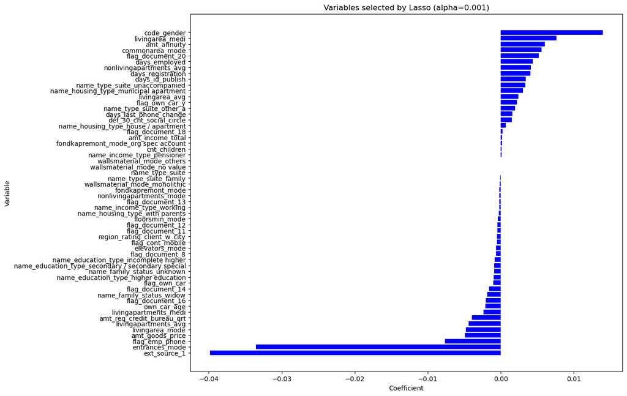

```python
# Train the Lasso model with alpha=0.001
lasso_orig = Lasso(alpha=0.001)
lasso_orig.fit(X_train_scaled, y_train)

# Get the coefficients from the Lasso model
lasso_coefs = lasso_orig.coef_  # Coefficients trained with alpha=0.001

# Create a DataFrame with variable names and their coefficients
lasso_features = pd.DataFrame({
    'variable': X_train_scaled.columns,
    'coefficient': lasso_coefs
})

# Filter variables with coefficients different from zero
selected_variables_lasso = lasso_features[lasso_features['coefficient'] != 0]

# Sort by the magnitude of the coefficients
selected_variables_lasso = selected_variables_lasso.sort_values(by='coefficient', ascending=False)

# Display the selected variables
print("Variables selected by Lasso (alpha=0.001):")
print(selected_variables_lasso)

# Number of selected variables
print(f"Total variables selected by Lasso: {selected_variables_lasso.shape[0]}")

# Plot the selected variables and their coefficients
plt.figure(figsize=(12, 10))
plt.barh(selected_variables_lasso['variable'], selected_variables_lasso['coefficient'], color='blue')
plt.xlabel("Coefficient")
plt.ylabel("Variable")
plt.title("Variables selected by Lasso (alpha=0.001)")
plt.gca().invert_yaxis()  # Invert the axis to show the most important variable at the top
plt.show()
```

El análisis mediante la regresión Lasso ha identificado un total de 56 variables que son cruciales para las predicciones del modelo. Entre las variables seleccionadas se destacan code_gender, livingarea_medi, amt_annuity, y flag_document_20, todas con coeficientes positivos significativos, lo que sugiere que estas variables tienen un impacto positivo considerable en las predicciones del modelo. Por otro lado, variables como entrances_mode y ext_source_1 tienen coeficientes negativos marcadamente grandes, indicando una influencia negativa significativa en las predicciones. Este enfoque permite reducir la complejidad del modelo al centrarse en las características más relevantes, mejorando así su interpretabilidad y potencialmente su rendimiento.

```python
lasso_selected = lasso_features[lasso_features['coefficient'] != 0]['variable']
```

```python
print(lasso_selected)

print("Number of selected variables:", lasso_selected.count())
```

```
0                                            amt_annuity
2                                        amt_goods_price
3                                       amt_income_total
7                              amt_req_credit_bureau_qrt
16                                          cnt_children
18                                           code_gender
23                                       commonarea_mode
25                                         days_employed
26                                       days_id_publish
27                                days_last_phone_change
28                                     days_registration
29                              def_30_cnt_social_circle
33                                        elevators_mode
38                                        entrances_mode
39                                          ext_source_1
```

[output cut: 43 more lines]

## Random Forest

El algoritmo Random Forest es fundamental en la estadística y el aprendizaje automático, utilizando múltiples árboles de decisión para mejorar la precisión y reducir el sobreajuste. Cada árbol en el bosque se entrena con diferentes subconjuntos de datos y variables, lo que aumenta la robustez del modelo.

La aplicación de Random Forest en la selección de variables preliminar es crucial, ya que evalúa la importancia de cada variable en las predicciones. Esto permite identificar las variables más relevantes, mejorando la eficiencia y la interpretabilidad del modelo predictivo.

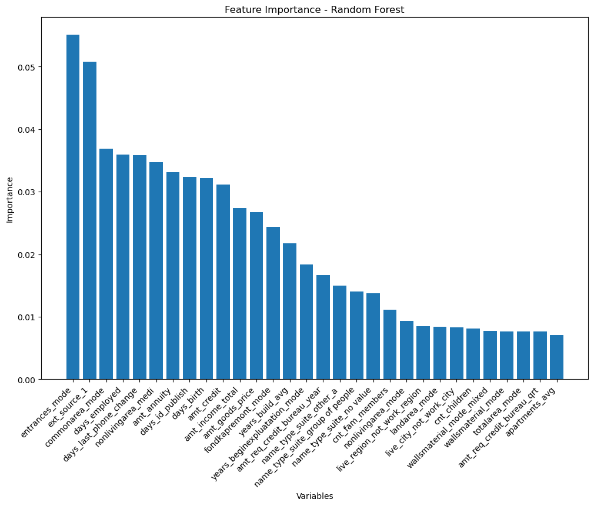

```python
# Create the Random Forest model
rf = RandomForestClassifier(random_state=seed, n_estimators=100)

# Train the model
rf.fit(X_train_scaled, y_train)

# Number of important variables to analyze
num_variables = 30

# Get feature importances
importances = rf.feature_importances_
indices = np.argsort(importances)[::-1]  # Sort from most to least important

# Create a plot of the most important variables
plt.figure(figsize=(12, 8))
plt.title("Feature Importance - Random Forest")
plt.bar(range(num_variables), importances[indices[:num_variables]], align="center")
plt.xticks(range(num_variables), X_train_scaled.columns[indices[:num_variables]], rotation=45, ha="right")
plt.xlabel("Variables")
plt.ylabel("Importance")
plt.show()
```

El gráfico de importancia de características del modelo de Random Forest revela las variables más influyentes en las predicciones del modelo. Se analizaron las 30 variables más importantes, visualizadas en un gráfico de barras donde el eje vertical representa la importancia y el eje horizontal muestra los nombres de las variables ordenadas de mayor a menor relevancia. Las variables que se destacan con barras más altas son aquellas que tienen el mayor impacto en la precisión del modelo. Por ejemplo, variables como entrances_node, ext_source_1, y days_employed aparecen como las más influyentes, sugiriendo que estas características son críticas para las predicciones del modelo. Este análisis es crucial para comprender cuáles son los factores que más contribuyen al modelo y para orientar futuros ajustes y optimizaciones.

Este gráfico no solo proporciona una visión clara de la jerarquía de las variables, sino que también es una herramienta poderosa para la toma de decisiones estratégicas. Conociendo qué variables son más importantes, se pueden realizar ajustes específicos en el modelo para mejorar su rendimiento, como eliminar características menos relevantes para simplificar el modelo sin sacrificar precisión. Además, esta información puede guiar la recolección de datos futuros, priorizando las variables más significativas y asegurando que los esfuerzos de recopilación de datos sean eficientes y efectivos. En síntesis, el análisis de importancia de características en un Random Forest, es un paso primoridial para maximizar el rendimiento del modelo y, del mismo modo, optimizar el uso de los recursos disponibles.

```python
rf_threshold = np.percentile(importances, 75)  # Threshold of 75%
rf_selected = X_train_scaled.columns[importances > rf_threshold]
```

```python
print(rf_selected)
```

```
Index(['amt_annuity', 'amt_credit', 'amt_goods_price', 'amt_income_total',
       'amt_req_credit_bureau_mon', 'amt_req_credit_bureau_qrt',
       'amt_req_credit_bureau_year', 'apartments_avg', 'apartments_medi',
       'apartments_mode', 'basementarea_avg', 'basementarea_medi',
       'basementarea_mode', 'cnt_children', 'cnt_fam_members', 'code_gender',
       'commonarea_mode', 'days_birth', 'days_employed', 'days_id_publish',
       'days_last_phone_change', 'days_registration', 'entrances_mode',
       'ext_source_1', 'flag_mobil', 'fondkapremont_mode',
       'fondkapremont_mode_reg oper spec account', 'hour_appr_process_start',
       'housetype_mode', 'landarea_mode', 'live_city_not_work_city',
       'live_region_not_work_region', 'name_income_type_working',
       'name_type_suite', 'name_type_suite_group of people',
       'name_type_suite_no value', 'name_type_suite_other_a',
       'nonlivingarea_medi', 'nonlivingarea_mode', 'totalarea_mode',
       'wallsmaterial_mode', 'wallsmaterial_mode_mixed',
       'years_beginexpluatation_mode', 'years_build_avg'],
      dtype='object')
```

### **Variables seleccionadas**

```python
selected_variables = set(rf_selected) | set(lasso_selected)
print(f"Total number of selected variables: {len(selected_variables)}")
```

```
Total number of selected variables: 83
```

```python
# Convert the set to a list to view the variable names
selected_variables_list = list(selected_variables)

# Display the names of the selected variables
print("Selected variables:")
for variable in selected_variables_list:
    print(variable)
```

```
Selected variables:
floorsmin_mode
name_income_type_pensioner
wallsmaterial_mode_monolithic
amt_req_credit_bureau_year
fondkapremont_mode
days_employed
name_housing_type_municipal apartment
fondkapremont_mode_org spec account
wallsmaterial_mode_others
name_type_suite
name_type_suite_other_a
nonlivingapartments_avg
cnt_fam_members
nonlivingapartments_mode
amt_req_credit_bureau_mon
name_education_type_secondary / secondary special
nonlivingarea_medi
region_rating_client_w_city
name_type_suite_group of people
hour_appr_process_start
flag_document_13
name_type_suite_family
landarea_mode
name_housing_type_house / apartment
days_registration
amt_goods_price
flag_own_car
flag_mobil
days_last_phone_change
ext_source_1
basementarea_avg
amt_annuity
totalarea_mode
amt_income_total
fondkapremont_mode_reg oper spec account
flag_document_8
entrances_mode
wallsmaterial_mode_mixed
commonarea_mode
```

[output cut: 29 more lines]

```
years_beginexpluatation_mode
basementarea_mode
name_housing_type_with parents
apartments_avg
apartments_medi
name_type_suite_no value
livingarea_avg
code_gender
flag_document_20
cnt_children
flag_emp_phone
name_education_type_higher education
livingarea_medi
flag_own_car_y
own_car_age
```

## Feature Engineering

El feature engineering es una técnica fundamental en la ciencia de datos y el aprendizaje automático. Se refiere al proceso de transformar datos en bruto en características que mejoren el rendimiento de los modelos predictivos. Este proceso implica la creación, modificación y selección de variables relevantes, permitiendo que los algoritmos de aprendizaje automático aprovechen mejor la información disponible.

```python
# Filter the data with the selected variables
X_train_selected = X_train_scaled[selected_variables]
X_test_selected = X_test_scaled[selected_variables]

def feature_engineering_selected(X_train, X_test):
    '''
    The feature_engineering_selected function applies preprocessing to the selected variables to ensure they are
    ready for training machine learning models. It includes:

    1. Missing value imputation: Fills NaN values with the median of the training set to maintain consistency.
    2. Standardization: Scales the selected variables to have a mean of 0 and a standard deviation of 1, ensuring compatibility with models sensitive to magnitudes.
    3. Outlier handling: Clips values outside the 1st and 99th percentiles to reduce the impact of outliers.
    4. Consistency between datasets: Ensures that the training and test data undergo the same transformations.

    This function produces preprocessed datasets, ready for model training and evaluation.
    '''

    X_train = X_train.copy()
    X_test = X_test.copy()

    ## 1. Handle missing values
    nan_cols_train = X_train.columns[X_train.isna().any()]
    for col in nan_cols_train:
        median_value = X_train[col].median()
        X_train[col].fillna(median_value, inplace=True)
        X_test[col].fillna(median_value, inplace=True)  # Use the training set median

    ## 2. Feature scaling
    from sklearn.preprocessing import StandardScaler
    scaler = StandardScaler()
    X_train_scaled = scaler.fit_transform(X_train)
    X_test_scaled = scaler.transform(X_test)

    X_train = pd.DataFrame(X_train_scaled, columns=X_train.columns)
    X_test = pd.DataFrame(X_test_scaled, columns=X_test.columns)

    ## 3. Handle outliers
    for col in X_train.columns:
        lower_bound = X_train[col].quantile(0.01)
        upper_bound = X_train[col].quantile(0.99)
        X_train[col] = np.clip(X_train[col], lower_bound, upper_bound)
        X_test[col] = np.clip(X_test[col], lower_bound, upper_bound)

    return X_train, X_test

# Apply feature engineering to the selected variables
X_train_final, X_test_final = feature_engineering_selected(X_train_selected, X_test_selected)

# Verify the result
print(f"Final training set dimensions: {X_train_final.shape}")
print(f"Final test set dimensions: {X_test_final.shape}")
```

```
Final training set dimensions: (246008, 83)
Final test set dimensions: (61503, 83)
```

```python
# View the final selected variables after processing
final_variables = X_train_final.columns.tolist()

print("Final selected variables:")
for variable in final_variables:
    print(variable)
```

```
Final selected variables:
floorsmin_mode
name_income_type_pensioner
wallsmaterial_mode_monolithic
amt_req_credit_bureau_year
fondkapremont_mode
days_employed
name_housing_type_municipal apartment
fondkapremont_mode_org spec account
wallsmaterial_mode_others
name_type_suite
name_type_suite_other_a
nonlivingapartments_avg
cnt_fam_members
nonlivingapartments_mode
amt_req_credit_bureau_mon
name_education_type_secondary / secondary special
nonlivingarea_medi
region_rating_client_w_city
name_type_suite_group of people
hour_appr_process_start
flag_document_13
name_type_suite_family
landarea_mode
name_housing_type_house / apartment
days_registration
amt_goods_price
flag_own_car
flag_mobil
days_last_phone_change
ext_source_1
basementarea_avg
amt_annuity
totalarea_mode
amt_income_total
fondkapremont_mode_reg oper spec account
flag_document_8
entrances_mode
wallsmaterial_mode_mixed
commonarea_mode
```

[output cut: 29 more lines]

```
years_beginexpluatation_mode
basementarea_mode
name_housing_type_with parents
apartments_avg
apartments_medi
name_type_suite_no value
livingarea_avg
code_gender
flag_document_20
cnt_children
flag_emp_phone
name_education_type_higher education
livingarea_medi
flag_own_car_y
own_car_age
```

```python
# Identify columns with low variance
low_variance_cols = X_train_final.columns[X_train_final.var() < 0.01]
print(f"Variables with low variance: {list(low_variance_cols)}")
```

```
Variables with low variance: ['fondkapremont_mode_org spec account', 'name_education_type_secondary / secondary special', 'flag_document_13', 'name_housing_type_house / apartment', 'flag_document_12', 'flag_document_14', 'flag_cont_mobile', 'flag_document_18', 'flag_document_16', 'flag_document_11',…
```

```python
# Remove columns with low variance
X_train_final.drop(columns=low_variance_cols, inplace=True)
X_test_final.drop(columns=low_variance_cols, inplace=True)
```

Al mantener estas variables, no solo se introduce ruido en el modelo, sino que también se incrementa innecesariamente la complejidad computacional, lo que puede afectar tanto el tiempo de entrenamiento como la interpretabilidad del modelo final. Por esta razón, se decidió eliminarlas para garantizar que los datos utilizados sean informativos y efectivos.

Este proceso también ayuda a mejorar la estabilidad del modelo frente a nuevos datos, ya que elimina características que podrían introducir ruido en lugar de aportar valor predictivo. En conjunto, la decisión de eliminar estas variables responde a las mejores prácticas en la preparación de datos para modelos de aprendizaje automático, asegurando que el enfoque se mantenga en las características que realmente impactan en el desempeño del modelo.

```python
# Update the set of selected variables by removing those with low variance
selected_variables = selected_variables - set(low_variance_cols)

print(f"Total selected variables after the update: {len(selected_variables)}")
```

```
Total selected variables after the update: 72
```

## Correlaciones entre variables finales y la variable objetivo

```
Correlations between final variables and the target variable:
entrances_mode                  0.161088
ext_source_1                    0.157496
years_beginexpluatation_mode    0.078482
commonarea_mode                 0.077682
years_build_avg                 0.072386
                                  ...
cnt_fam_members                 0.007979
nonlivingapartments_mode        0.006645
region_rating_client_w_city     0.005125
flag_document_8                 0.003140
nonlivingarea_medi              0.003003
Name: target, Length: 72, dtype: float64
```

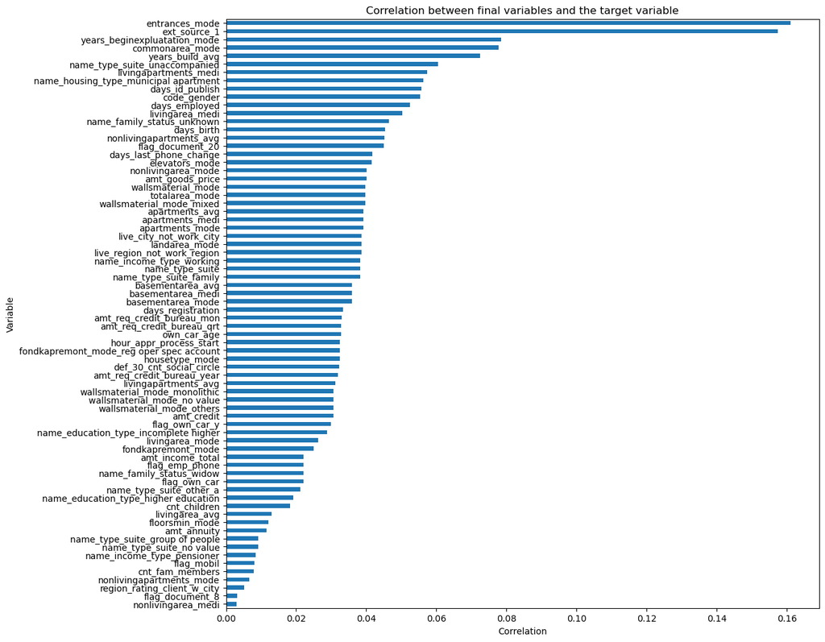

```python
# Ensure y_train is a pandas Series
y_train_series = pd.Series(y_train, name='target')

# Combine X_train_final with y_train_series to calculate correlation
df_combined = pd.concat([X_train_final, y_train_series], axis=1)

# Calculate the correlation matrix
correlation_matrix = df_combined.corr()

# Select the correlation with the target variable
correlation_with_target = correlation_matrix['target'].drop('target')

# Sort the correlations in descending order
correlation_with_target = correlation_with_target.abs().sort_values(ascending=False)

# Display the variables most correlated with the target variable
print("Correlations between final variables and the target variable:")
print(correlation_with_target)

# Optional: Plot the correlations
import matplotlib.pyplot as plt

plt.figure(figsize=(12, 12))
correlation_with_target.plot(kind='barh')
plt.title("Correlation between final variables and the target variable")
plt.xlabel("Correlation")
plt.ylabel("Variable")
plt.gca().invert_yaxis()
plt.show()
```

El análisis de correlaciones realizado entre las variables predictoras y la variable objetivo reveló resultados coherentes y esperados. Las variables con las correlaciones más altas, en torno a 0.15-0.16, como "entrances_mode" y "ext_source_1", demuestran una relación lineal moderada con la variable que se desea predecir. Esto es típico en conjuntos de datos reales, donde rara vez se encuentran correlaciones excepcionalmente elevadas. Por otro lado, las variables con correlaciones en el rango de 0.05-0.08, como "years_beginexpluatation_mode", "commonarea_mode" y "years_build_avg", sugieren una asociación más débil pero aún relevante. La gran mayoría de las características presentan correlaciones por debajo de 0.05, lo cual, si bien no las descarta como predictores potencialmente útiles, indica que su contribución individual a la predicción de la variable objetivo probablemente será limitada. Incluso se identificaron algunas variables con correlaciones casi nulas, como "flag_document_8", las cuales podrían ser candidatas a ser excluidas del modelo a menos que aporten valor en conjunto con otras variables. En general, los resultados del análisis de correlaciones reflejan un panorama típico para este tipo de datos, proporcionando un punto de partida sólido para continuar con el desarrollo y refinamiento del modelo predictivo.

Por último, es oportuno señalar que, la variable **code_gender** se mantuvo en el análisis debido a su correlación significativa con la variable objetivo. Aunque no es la variable con mayor influencia, su relevancia estadística justifica su inclusión en el modelo predictivo. Esta decisión es fundamental para capturar diferencias importantes basadas en el género, lo que podría influir en los resultados del estudio. Es crucial señalar que se tomaron en cuenta las normativas éticas y legales aplicables para garantizar un manejo responsable de los datos personales. Así pues, la variable code_gender se conservo debido a su impacto significativo y comprobado en la variable objetivo, considerando de manera adecuada las normativas de protección de datos vigentes.

## Guardar los datos procesados

```python
# Convert y_train and y_test to DataFrames
y_train_df = pd.DataFrame(y_train)
y_test_df = pd.DataFrame(y_test)

# Save the processed datasets
X_train_final.to_csv("../data/preprocessed_data/X_train_final.csv", index=False)
X_test_final.to_csv("../data/preprocessed_data/X_test_final.csv", index=False)
y_train_df.to_csv("../data/preprocessed_data/y_train.csv", index=False)
y_test_df.to_csv("../data/preprocessed_data/y_test.csv", index=False)

# Save the names of the final variables
pd.DataFrame(final_variables, columns=["Variable"]).to_csv("../data/preprocessed_data/final_variables.csv", index=False)

print("The datasets and selected variables have been saved successfully.")
```

```
The datasets and selected variables have been saved successfully.
```

En esta sección, hemos llevado a cabo el procesamiento y la selección de las variables más relevantes para nuestro análisis. Los conjuntos de datos procesados (tanto de entrenamiento como de prueba) y los nombres de las variables seleccionadas han sido guardados exitosamente en archivos CSV. Esto garantiza que los datos estén listos para ser utilizados en los siguientes pasos del análisis.

A continuación, utilizaremos las variables seleccionadas para construir y entrenar el modelo predictivo. Este modelo nos permitirá evaluar el rendimiento y la precisión de nuestras predicciones, aprovechando las características más significativas identificadas en el proceso de selección de variables.